# Model and Analysis

Lawson et al

2023-06-19

# I. Load parameters

[output not shown]

# II. Define functions

Define function where variable is either `x` i.e population stock, or `s` i.e price paid to poachers. All the parameters take default values specified in the global environment.

- `growth(x, ...)` : logistic growth function, yields growth of population (in metric tons)
- `pt_harvest(x,...)` : harvest (in metric tons) when trader is price taker
- `monop_harvest(x, ...)`: harvest (in metric tons) when trader is a monopolist
- `cournot_harvest(x, ...)`, `bertrand_harvest(x, ...)`: harvest (in metric tons) when trader and farmer compete in *Cournot*, i.e, set quantities strategically, and *Bertrand*, i.e, set prices strategically.
- `price_poachers_cournot(x, ...)`, `price_poachers_bertrand(x, ...)`: price paid to poachers (in USD/metric tons) when trader and farmer compete in *Cournot* and *Bertrand*
- `cournot_farmed(s, ...)`, `bertrand_farmed(s, ...)`: quantity farmed (in metric tons) when trader and farmer compete in *Cournot* and *Bertrand*

# III. Generate results

Generate results saved at `~/data/result1.csv`.

```
##   x    growth    pt_harvest     ss_pt monop_harvest  ss_monop cournot_harvest
## 1 1 0.2012727 0.00007468313 0.2011981  0.0001493662 0.2011234   0.00008492275
## 2 2 0.4025256 0.00029873246 0.4022268  0.0005974644 0.4019281   0.00033969075
## 3 3 0.6037585 0.00067214779 0.6030863  0.0013442930 0.6024142   0.00076430332
## 4 4 0.8049715 0.00119492880 0.8037766  0.0023898494 0.8025817   0.00135875928
## 5 5 1.0061646 0.00186707505 1.0042976  0.0037341300 1.0024305   0.00212305699
## 6 6 1.2073379 0.00268858595 1.2046493  0.0053771302 1.2019607   0.00305719436
##   price_poachers_cournot cournot_farmed ss_cournot bertrand_harvest
## 1               924375.6       498.4175  0.2011878    0.00004105786
## 2               924375.0       498.4174  0.4021859    0.00016423139
## 3               924373.9       498.4172  0.6029942    0.00036952049
## 4               924372.5       498.4170  0.8036128    0.00065692497
## 5               924370.5       498.4166  1.0040416    0.00102644459
## 6               924368.2       498.4162  1.2042807    0.00147807902
##   price_poachers_bertrand bertrand_farmed ss_bertrand
## 1                446910.7        837.6766   0.2012317
## 2                446910.6        837.6765   0.4023613
## 3                446910.4        837.6763   0.6033890
## 4                446910.2        837.6761   0.8043146
## 5                446909.9        837.6758   1.0051382
## 6                446909.5        837.6755   1.2058598
```

Use `result1` to produce steady states:

| Market structure | Stock | Harvest | Farmed |
| --- | --- | --- | --- |
| Price taker | 12606 | 955.9557 | NA |
| Monopoly | 17230 | 513.8276 | NA |
| Cournot | 18208 | 365.7974 | 333.8087 |
| Betrand | 17072 | 535.9869 | 432.3084 |

1. **Monopoly scenario** with cost parameter c=0 is a 36.68, % variation in *population stock* in tonnes (compared to OA) or, equivalently, of 179922 adult totoabas
2. **Monopoly scenario** with cost parameter c= 0 is a difference of 442.13(in tons) in *harvest* or, equivalently, of 17203 adult totoabas
3. **Worst case scenario** with cost parameter c=0 is a -0.92 % variation in *population stock* in tonnes or, equivalently, of -6148 adult totoabas
4. **Worst case scenario** with cost parameter c=0 is a difference of 22.16 (tons) in *harvest* or, equivalently, of -862.23 adult totoabas
5. **Best case scenario** with cost parameter c=0 is a 5.68 % variation in *population stock* in tonnes or, equivalently, of 38054.47 adult totoabas
6. **Best case scenario** with cost parameter c=0 is a difference of -148.03 (in tons) in harvest in tonnes or, equivalently, of 5759.93 adult totoabas

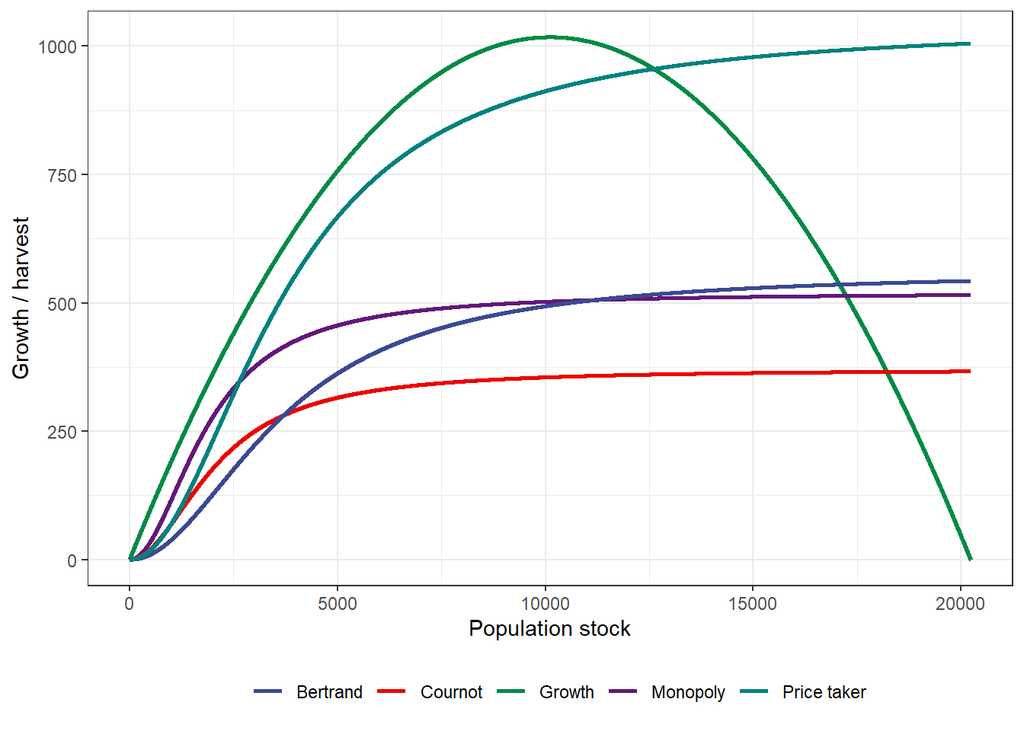